# Calculate access to pre-kindergarten Predictor, Place-level

Author

JP Walsh

Published

March 3, 2025

*Program for the creation of the Access to Pre-Kindergarten Upward Mobility Predictor at the place-level*

ACS Code: Initially written by Tina Chelidze and updated by JP Walsh 2025.

Primary data derived from the IPUMS API.

Based on processes developed by Paul Johnson and Kevin Werner in SAS.

*User note* This program depends on extracts from the IPUMS ACS API interface. If you are updating the extract please remember to update the extract_date to reflect the time of the latest extract in the Housekeeping section of this program.

Please select your year by updating ‘params$year’ in the YAML parameters above.

*Internal users* If you are an internal tester using the AWS feature of this program remember to enter the passkey into your environment using Sys.setenv(). Authentication steps are nicely explained in this [blog](https://www.gormanalysis.com/blog/connecting-to-aws-s3-with-r/). You will have to request access to the access key.

*User warning* The ACS micro data used to create this metric is large and will take time to read in. It is strongly recommended that you use a server with significant computing power to run this. For internal Urban Institute users, the SAS server provides a good option.

## Housekeeping

Read in packages for use. If you do not have an IPUMS API key you will need to make one via the [IPUMS website](https://www.ipums.org/).

```r
library(tidyverse)
library(Hmisc)
library(ipumsr)
library(reactable)
library(srvyr)
library(scales)


options(scipen = 999)

# DO NOT PUSH YOUR API KEY. You only have to run this once and then comment it out as below.
#set_ipums_api_key("Your KEY", save = TRUE)

s3_dir <- "metric_name/data/acs"
my_bucket <- "mobility-from-poverty-test"

source(here::here("functions", "API", "extract_ipums_aws.R"))
source(here::here("functions", "API", "ipums_repwt_pre-k_aws.R"))
source(here::here("functions", "testing", "evaluate_final_data.R"))
source(here::here("08_education", "R", "finalize_metric.R"))
source(here::here("08_education", "R", "calc_survey_mean.R"))
source(here::here("08_education", "R", "calc_survey_mean_subgroup.R"))
```

Date of IPUMS extract. Denote the latest date that the IPUMS extract was changed and pulled both for the overall data and the repweights. The recommended date notation format is “mm_dd_yy”.

For internal reviewers, if you plan to utilize AWS keep this date as it was last entered by the metric lead unless you intend to change the extract.

```r
ipums_extract_date <- "02_28_25"
ipums_repwt_extract_date <- "02_28_25"
```

If this is to update a single year of new data please set single_year_update to “Yes”. If not, set it to “No”.

```r
single_year_update = "No"
```

Define existing intermediate years and read them into function to combine.

```r
existing_years <- c("2014", "2016", "2018", "2021", "2023")
```

## Read Person-Level Data

Read in the ACS extracts using the `extract_ipums()` function. Make sure to change the survey list to reflect what years you want to include in the data. The surveys being used in the code are defined in the code chunk below. For a list of available ACS surveys and their titles via the IPUMSR package you can run the following function: get_sample_info(“acs”).

```r
acs_surveys <- list(paste0("us", params$year, "c"))
```

Run extract. This will trigger an import process through IPUMS. It is encouraged to add detail to your extract description so it is clear what the extract was used for.

Date of latest extract noted above. If a new IPUMS pull is required the extract_date argument below must be updated to track that new data was downloaded. The extract only needs to be updated if changes or additions are required from the IPUMS pull (such as new dates or variables).

```r
acs <- extract_ipums_aws(
  extract_name = paste0("umf_data_", params$year, "_5year_acs"),
  extract_date = ipums_extract_date,
  extract_description = paste0("Microdata pull for Access to Pre-K Metric Predictors. American Community Survey", params$year, "(5-year)."),
  survey = acs_surveys
)
```

Look at the survey year of the IPUMS data. The survey year should match what was selected in the `extract_ipums()` function above.

```r
count(acs, sample)
```

```
# A tibble: 1 x 2
  sample                       n
  <fct>                    <int>
1 2019-2023, ACS 5-year 15912393
```

Isolate the data to 3 and 4 year-olds. This is the age-range included in the pre-K calculation. Note: the replicate weights are limited to these ages during the data pull.

```r
acs_age <- acs %>%
  filter(age == 3 | age == 4)

rm(acs)
```

### Replicate Weights

Read in person-level replicate weights for the 3 and 4 year old population. These will be used in creating standard errors for the preschool access calculation.

Date of latest extract listed above. If a new IPUMS pull is required the extract_date argument below must be updated to track that new data was downloaded. The extract only needs to be updated if changes or additions are required from the IPUMS pull (such as new dates or variables).

Note that `ipums_repwt_pre_k_aws` filters the age of respondents directly during the IPUMS API call.

```r
repwts <- ipums_repwt_pre_k_aws(
  extract_name = paste0("preschool_replicate_weights_", params$year),
  extract_date = ipums_repwt_extract_date,
  extract_description = paste0("Person replicate weights for Access to Preschool Metric Predictors. American Community Survey,", params$year, "(5-year)."),
  survey = acs_surveys
)  %>%
  select(-cbserial, -cbpernum)
```

Look at the sample year of the IPUMS repwt data. The sample should align with the survey selected in the `ipums_repwt_pre_k_aws` function.

```r
count(repwts, sample)
```

```
# A tibble: 1 x 2
  sample                     n
  <fct>                  <int>
1 2019-2023, ACS 5-year 310609
```

Remove the sample variable.

```r
repwts_person <- repwts %>%
  select(-sample)
```

### Merge on repwts

```r
length(unique(pull(acs_age, unique_person_id)))
```

```
[1] 310609
```

```r
length(unique(pull(repwts_person, unique_person_id)))
```

```
[1] 310609
```

```r
acs_combined <-
  full_join(
    acs_age,
    repwts_person,
    by = "unique_person_id"
  )

length(unique(pull(acs_combined, unique_person_id)))
```

```
[1] 310609
```

```r
stopifnot(nrow(acs_combined) == nrow(acs_age))
stopifnot(nrow(acs_combined) == nrow(repwts_person))

rm(acs_age)
rm(repwts_person)
```

Check that the merge did not result in any missing values.

```r
stopifnot(all(map_dbl(acs_combined, ~sum(is.na(.x))) == 0))
```

## Clean Data

Missing data is reported in a variety of ways by IPUMS data. This step walks through the missing values in key variables and checks that we are dealing with them appropriately.

- **Age:** No missing values reported in variable description. Run the following test to confirm all values are either 3 or 4.

```r
stopifnot(all(acs_combined$age %in% c(3, 4)))
```

- **Vacancy:** reported as “0”. Note there should be no vacancy results by default of the structure of census data read in (all should be “0”). Confirm this is true with the following test.

```r
stopifnot(all(acs_combined$vacancy == "0"))
```

- **Gradeatt:** N/As reported as “0” in all modern surveys. In this analysis we assume that a zero reported means that the individual is not in school. Variable codes explained [here](https://usa.ipums.org/usa-action/variables/GRADEATT#codes_section).

There is a significant share of records reported as “0” for the grade level attending variable.

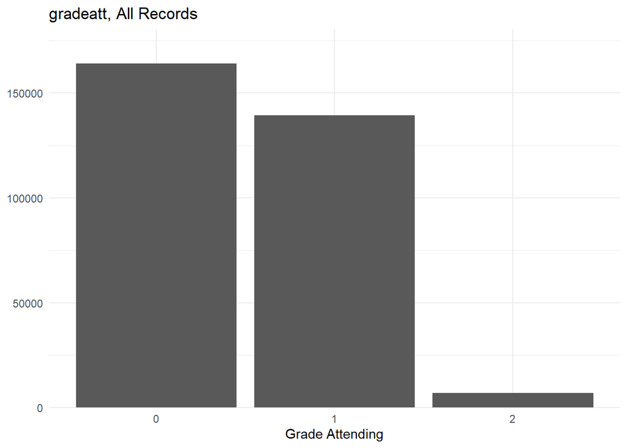

```r
acs_combined %>%
  mutate(gradeatt = zap_labels(gradeatt)) %>%
  count(gradeatt) %>%
  ggplot(mapping = aes(x = factor(gradeatt), y = n)) +
  geom_col() +
  theme_minimal() +
  ggtitle("gradeatt, All Records") +
  scale_y_continuous(expand = expansion(mult = c(0, 0.1))) +
  labs(x = "Grade Attending",
       y = NULL)
```

Confirm the values from the value labels of the GRADEATT variable to ensure we are interpreting them correctly. 1 is Nursery school/preschool and 0 is N/A - interpreting as not in school for the sake of this analysis.

```r
head(acs_combined$gradeatt)
```

```
<labelled<integer>[6]>: Grade level attending [general version]
[1] 0 0 0 1 1 0

Labels:
 value                           label
     0                             N/A
     1        Nursery school/preschool
     2                    Kindergarten
     3              Grade 1 to grade 4
     4              Grade 5 to grade 8
     5             Grade 9 to grade 12
     6           College undergraduate
     7 Graduate or professional school
```

Rename to the more meaningful “grade_attending”. And turn the variable into a factor so we can use the labels which provide clear descriptions of the grades.

```r
acs_clean <- acs_combined %>%
  mutate(grade_attending = as_factor(gradeatt))
```

Examine the group quarters, `gq`, variable, we want to include both households and Group Quarters in this metric as both are relevant to the preschool access predictor in a geography.

IPUMS includes the following categories:

- 0: Vacancy
- 1: Households under 1970 definition
- 2: Additional households under 1990 definition
- 3: Institutions
- 4: Other group quarters
- 5: Additional households under 2000 definition
- 6: Fragments

Check the distribution of GQ categories. Only households and group quarters should be included (no vacancy or fragments).

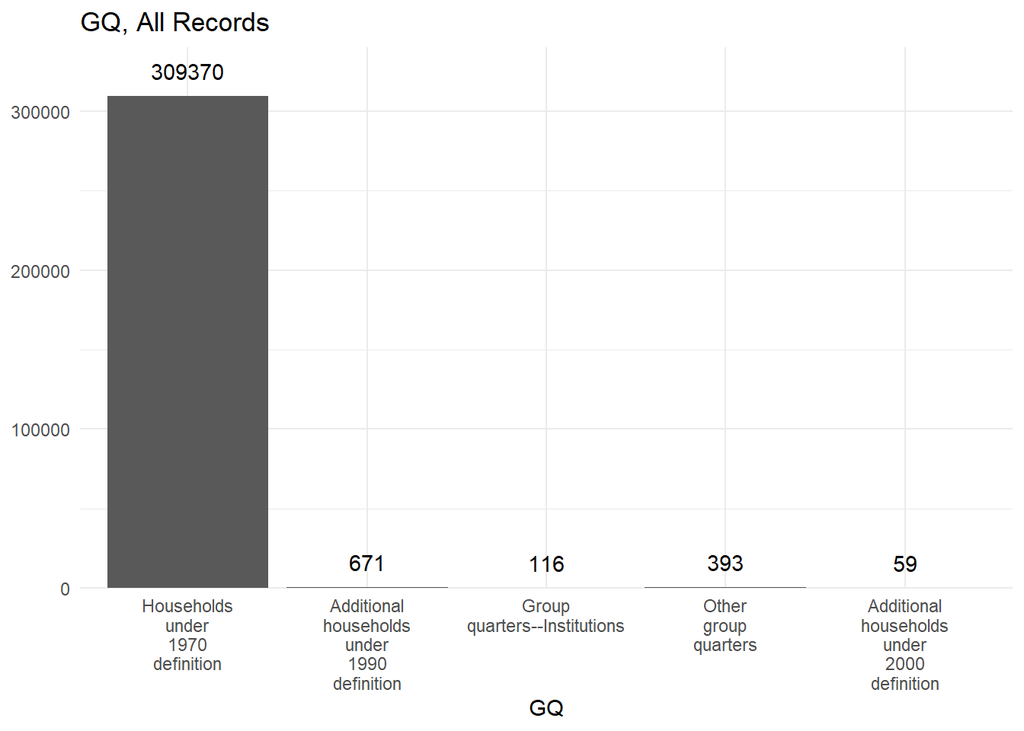

```r
acs_clean %>%
  count(gq) %>%
  ggplot(mapping = aes(x = gq, y = n)) +
  geom_col() +
  theme_minimal() +
  ggtitle("GQ, All Records") +
  geom_text(mapping = aes(label = n), vjust = -1) +
  scale_y_continuous(expand = expansion(mult = c(0, 0.1))) +
  labs(x = "GQ",
       y = NULL)+
  scale_x_discrete(labels = label_wrap(10))
```

### Create race variable

Evaluate the values in the RACE and HISPAN variables.

- IPUMS documented values for RACE:
  - 1 White
  - 2 Black/African American/Negro
  - 3 American Indian or Alaska Native
  - 4 Chinese
  - 5 Japanese
  - 6 Other Asian or Pacific Islander
  - 7 Other race
  - 8 Two major races
  - 9 Three or more major races
- IPUMS documented values for HISPAN:
  - 0 Not Hispanic
  - 1 Mexican
  - 2 Puerto Rican
  - 3 Cuban
  - 4 Other
  - 9 Not Reported

Look at the distribution of values for the race and hispan variables.

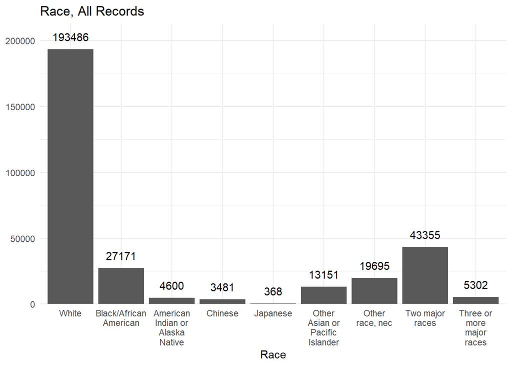

```r
acs_clean %>%
  count(race) %>%
  ggplot(mapping = aes(x = race, y = n)) +
  geom_col() +
  theme_minimal() +
  ggtitle("Race, All Records") +
 geom_text(mapping = aes(label = n), vjust = -1) +
  scale_y_continuous(expand = expansion(mult = c(0, 0.1))) +
  labs(x = "Race",
       y = NULL)+
  scale_x_discrete(labels = label_wrap(10))
```

Create the race/ethnicity variable. For race/ethnicity categories that are not coded as Hispanic, Hispan must be equal to “Not Hispanic”.

Rename the values from number category to race label:

- Race is Black/African American and Hispan is Not Hispanic = “Black, Non-Hispanic”
- Hispan is not equal to Not Hispanic = “Hispanic”
- Race is not Black or White and Hispan is Not Hispanic = “Other Races and Ethnicities”
- Race is White and Hispan is Not Hispanic = “White, Non-Hispanic”

```r
acs_clean <- acs_clean %>%
  mutate(
    subgroup_race = case_when(
      hispan != "Not Hispanic" ~ "Hispanic",
      race == "White" ~ "White, Non-Hispanic",
      race == "Black/African American" ~ "Black, Non-Hispanic",
      !race %in% c("Black/African American", "White") ~ "Other Races and Ethnicities"
    )
  )
```

Look at the race/ethnicity subgroup distribution.

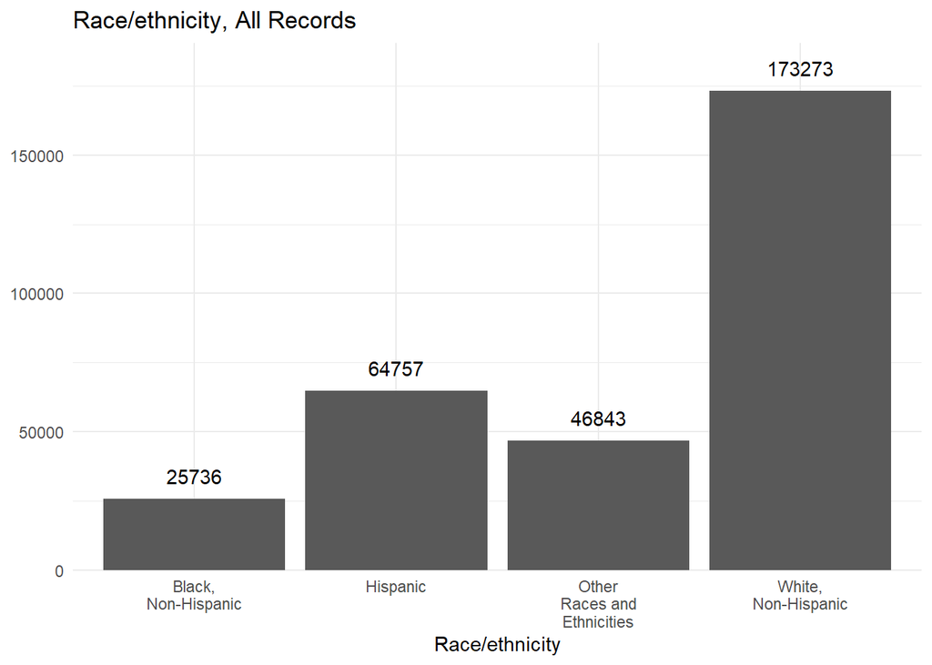

```r
acs_clean %>%
  count(subgroup_race) %>%
  ggplot(mapping = aes(x = factor(subgroup_race), y = n)) +
  geom_col() +
  theme_minimal() +
  ggtitle("Race/ethnicity, All Records") +
 geom_text(mapping = aes(label = n), vjust = -1) +
  scale_y_continuous(expand = expansion(mult = c(0, 0.1))) +
  labs(x = "Race/ethnicity",
       y = NULL)+
  scale_x_discrete(labels = label_wrap(10))
```

### Create poverty variable

- **HHINCOME:** N/As reported as “9999999”.

There are several cases of records missing HHINCOME, which extends the density distribution tail out to 9999999.

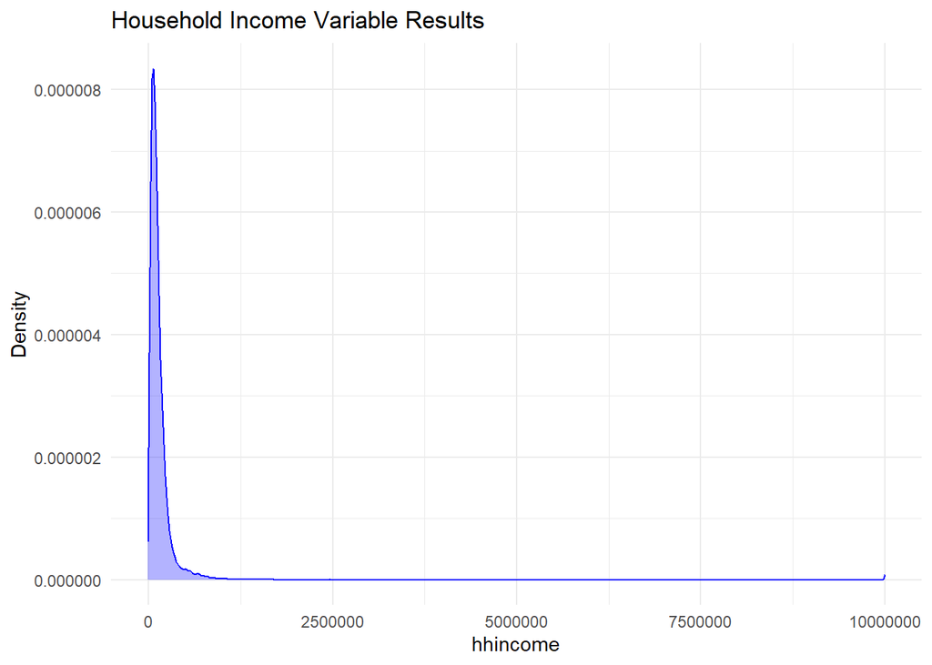

```r
acs_clean %>%
  ggplot(aes(x = hhincome)) +
  geom_density(color = "blue", fill = alpha("blue", 0.3)) +
  theme_minimal() +
  ggtitle("Household Income Variable Results") +
  ylab("Density")
```

Turn the missing/“not in universe” values for the `hhincome` variable into NAs. Rename to the more meaningful “household_income”.

```r
acs_clean <- acs_clean %>%
  mutate(household_income = ifelse(hhincome == 9999999, NA_integer_,
                          hhincome)
  )
```

Look at distribution of `household_income` after adjustment. Some outliers will still exist but bunching around the missing value should not be present.

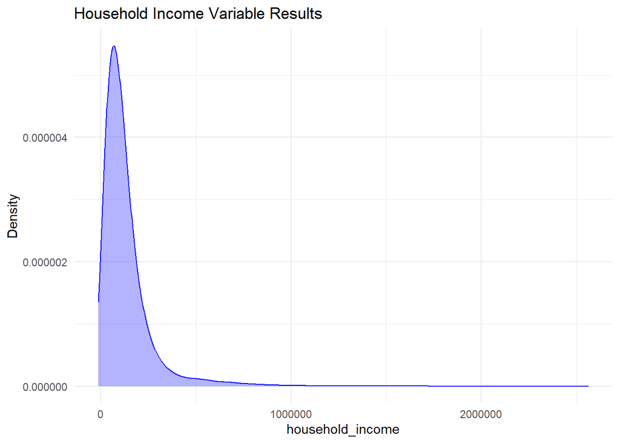

```r
acs_clean %>%
  ggplot(aes(x = household_income)) +
  geom_density(adjust = 5, color = "blue", fill = alpha("blue", 0.3)) +
  theme_minimal() +
  ggtitle("Household Income Variable Results") +
  ylab("Density")
```

For the poverty subgroup we want to put each respondent into two groups: those that live in households earning more than 50,000 dollars a year and those in households earning less than 50,000 dollars a year.

First, create a binary variable indicating whether household income falls above or below 50,000 dollars a year.

```r
acs_clean <- acs_clean %>%
  mutate(subgroup_income = case_when(household_income >= 50000 ~ "$50,000 or More",
                                     household_income < 50000 ~ "Less than $50,000",
         TRUE ~ NA_character_))
```

Visualize the distribution of the income category. There are significantly more respondents in households earning above 50,000 dollars a year and relatively few NAs.

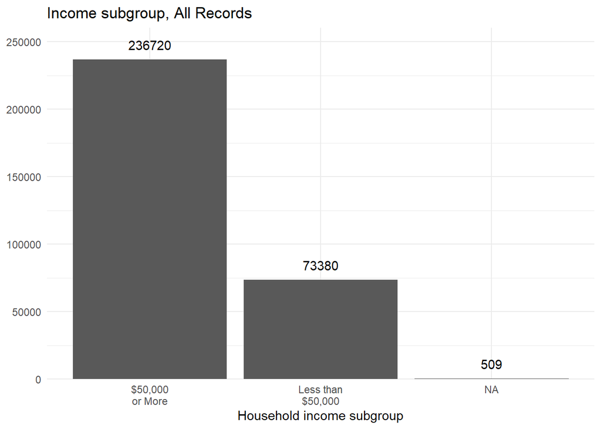

```r
acs_clean %>%
  count(subgroup_income) %>%
  ggplot(mapping = aes(x = factor(subgroup_income), y = n)) +
  geom_col() +
  theme_minimal() +
  ggtitle("Income subgroup, All Records") +
 geom_text(mapping = aes(label = n), vjust = -1) +
  scale_y_continuous(expand = expansion(mult = c(0, 0.1))) +
  labs(x = "Household income subgroup",
       y = NULL)+
  scale_x_discrete(labels = label_wrap(10))
```

## Crosswalk

Read in the PUMA to place crosswalk file. This file is created by the program generate_puma_place_crosswalks.rmd in the geographic-crosswalks folder.

```r
puma_place_crosswalk <- read_csv(
  here::here("geographic-crosswalks", "data", "crosswalk_puma_to_place.csv")
)
```

Create a version with just unique places for creating a version of the data that matches the UMF place list.

```r
place_list <- puma_place_crosswalk %>%
  select(statefip, place) %>%
  filter(statefip != 72) %>%
  unique()
```

## Merge Crosswalk

Create a variable in the ACS data indicating whether the survey year is pre or post-2022. This will be used to join on the correct crosswalk information.

```r
acs_clean <- acs_clean %>%
  mutate(crosswalk_period = ifelse(year < 2022, "pre-2022", "2022"))
```

Check that the assignment worked. All years prior to 2022 should be designated “pre-2022”.

```r
count(acs_clean, crosswalk_period, year)
```

```
# A tibble: 1 x 3
  crosswalk_period  year      n
  <chr>            <int>  <int>
1 2022              2023 310609
```

Join the cleaned ACS data onto the crosswalk.

```r
acs_crosswalked <- left_join(
  acs_clean,
  puma_place_crosswalk,
  by = c("crosswalk_period", "statefip","puma"),
  relationship = "many-to-many"
)

rm(acs_clean)
```

Check that each place has joined to many ACS records. We select the largest 486 places in our crosswalk, all 486 unique places should be connected to multiple records.

```r
acs_crosswalked %>%
  group_by(place, statefip) %>%
  count()
```

```
# A tibble: 536 x 3
# Groups:   place, statefip [536]
   place statefip     n
   <chr> <chr>    <int>
 1 00562 06         163
 2 00884 06          93
 3 01000 36          59
 4 01000 39         444
 5 01000 48         450
 6 01000 51         188
 7 01924 48         385
 8 02000 06        1246
 9 02000 35         427
10 02000 42          73
# i 526 more rows
```

Drop any observations with NA for `afact` (i.e. there is no place of interest overlapping this PUMA).

```r
count(acs_crosswalked, is.na(afact))
```

```
# A tibble: 2 x 2
  `is.na(afact)`      n
  <lgl>           <int>
1 FALSE          181856
2 TRUE           167763
```

```r
acs_crosswalked <- acs_crosswalked %>%
  drop_na(afact)
```

Also filter out cases where `afact` is equal to zero. These cases will not be counted in the metric calculation.

```r
count(acs_crosswalked, afact == 0)
```

```
# A tibble: 1 x 2
  `afact == 0`      n
  <lgl>         <int>
1 FALSE        181856
```

```r
acs_crosswalked <- acs_crosswalked %>%
  filter(afact > 0)
```

Adjust the person weight to account for PUMA-to-place mapping (those where the PUMA is not entirely inside the place).

```r
select(acs_crosswalked, perwt, repwtp1, repwtp80, afact)
```

```
# A tibble: 181,856 x 4
   perwt repwtp1 repwtp80  afact
   <dbl>   <dbl>    <dbl>  <dbl>
 1     2       2        0 0.968
 2     2       3        3 0.887
 3     2       0        3 0.873
 4    18      15       27 0.0519
 5    18      15       27 0.113
 6    26      31       44 0.183
 7     7       2        7 0.0326
 8    10      17       11 0.0111
 9    12      26       12 0.837
10    36      33       13 0.0139
# i 181,846 more rows
```

```r
acs_crosswalked <- acs_crosswalked %>%
  mutate(perwt = perwt * afact) %>%
  mutate(across(matches("repwtp[0-9]+"), ~.x * afact))

select(acs_crosswalked, perwt, repwtp1, repwtp80, afact)
```

```
# A tibble: 181,856 x 4
    perwt repwtp1 repwtp80  afact
    <dbl>   <dbl>    <dbl>  <dbl>
 1  1.94   1.94      0     0.968
 2  1.77   2.66      2.66  0.887
 3  1.75   0         2.62  0.873
 4  0.934  0.778     1.40  0.0519
 5  2.03   1.69      3.05  0.113
 6  4.76   5.68      8.06  0.183
 7  0.228  0.0652    0.228 0.0326
 8  0.111  0.189     0.122 0.0111
 9 10.0   21.8      10.0   0.837
10  0.500  0.459     0.181 0.0139
# i 181,846 more rows
```

### Create additional variables

Create a binary preschool variable indicating whether the child is in preschool/pre-K or not. IPUMS codes Nursery school/preschool (1) and N/A (0) (re: grade level attending). The way the code was built in prior years it is assumed N/A means that the child is not attending any school.

```r
acs_crosswalked <- acs_crosswalked %>%
  filter(grade_attending %in% c("Nursery school/preschool", "N/A", "Kindergarten")) %>%
  mutate(preschool = grade_attending == "Nursery school/preschool")
```

Evaluate the share of 3/4 year olds in kindergarten in each state. The share varies by state, with some states reaching upwards of 6 percent of 3/4 year olds being in Kindergarten.

```r
acs_crosswalked %>%
  group_by(statefip) %>%
  summarise(
    wtd_3_4yo = sum(perwt),
    wtd_kind = sum(perwt[grade_attending == "Kindergarten"]),
    count_3_4yo = n(),
    count_kind = sum(grade_attending == "Kindergarten"),
    shr_kindergarten_weighted = wtd_kind/wtd_3_4yo,
    shr_kindergarten_record_count = count_kind/count_3_4yo
  ) %>%
  select(statefip, shr_kindergarten_weighted, shr_kindergarten_record_count) %>%
  reactable(
    columns = list(
      shr_kindergarten_weighted = colDef(format = colFormat(percent = TRUE, digits = 1)),
      shr_kindergarten_record_count = colDef(format = colFormat(percent = TRUE, digits = 1))
    )
  )
```

| statefip | shr_kindergarten_weighted | shr_kindergarten_record_count |
| --- | --- | --- |
| 01 | 0.0191296489668023 | 0.0192081536652293 |
| 02 | 0.0261729586298396 | 0.0256410256410256 |
| 04 | 0.022263482039025 | 0.0219575735020469 |
| 05 | 0.0154291896925003 | 0.0110062893081761 |
| 06 | 0.0314362138046985 | 0.0276480903687171 |
| 08 | 0.0276519804116424 | 0.0188749766398804 |
| 09 | 0.0733027382579203 | 0.0646651270207852 |
| 11 | 0.0604626397680885 | 0.0426621160409556 |
| 12 | 0.0339124720922245 | 0.0345386890563877 |
| 13 | 0.016662382112632 | 0.0182068017863277 |

[output cut: 36 more lines]

Check if `grade_attending` is ever `NA`.

```r
stopifnot(sum(is.na(acs_crosswalked$grade_attending)) == 0)
```

Confirm there are no vacant properties included in the data.

```r
stopifnot(sum(is.na(acs_crosswalked$vacancy)) == 0)
```

Check the distribution of the `grade_attending` variable one last time - there should be no NA values included.

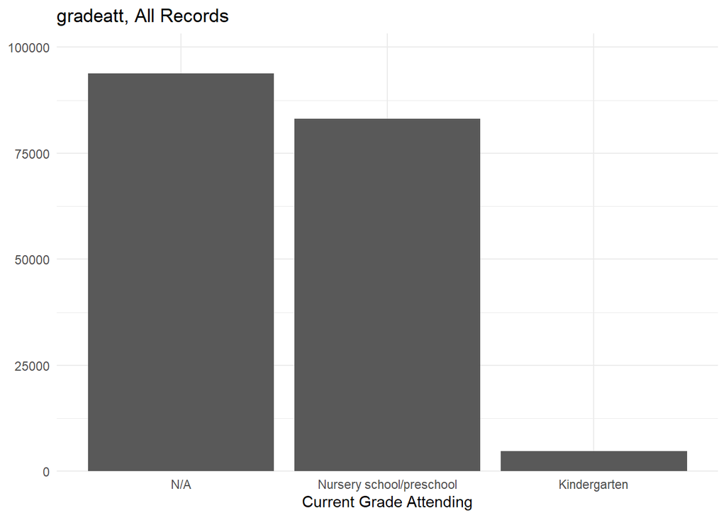

```r
acs_crosswalked %>%
  count(grade_attending) %>%
  ggplot(mapping = aes(x = factor(grade_attending), y = n)) +
  geom_col() +
  theme_minimal() +
  ggtitle("gradeatt, All Records") +
  scale_y_continuous(expand = expansion(mult = c(0, 0.1))) +
  labs(x = "Current Grade Attending",
       y = NULL)
```

## Create pre-K metric: All

### Pre-drop suppressed cells

First, to save time when processing the metric, calculate the effective sample count for each place, defined as the sum of the `afact` variable. This is used to create a cutoff for data quality based on the actual number of survey records being used in the calculation. We will not include places with less than 30 effective samples.

```r
acs_all <- acs_crosswalked %>%
  group_by(year, sample, crosswalk_period, statefip, place) %>%
  mutate(effective_sample = sum(afact)) %>%
  ungroup()

# calculate the number of statistics after suppressing values
acs_all %>%
  group_by(year, sample, crosswalk_period, statefip, place) %>%
  summarise(
    effective_sample = max(effective_sample)
  ) %>%
  ungroup() %>%
  summarise(
    original_stats = n(),
    unsuppressed_stats = sum(effective_sample >= 30)
  )
```

```
# A tibble: 1 x 2
  original_stats unsuppressed_stats
           <int>              <int>
1            486                486
```

Create the preschool access metric.

Objective: calculate the percent of individuals between 3 and 4 that are in pre-K or higher.

Aggregation should be weighted by PERWT (this is a person level statistic).

Remove records from places below the size quality cutoff.

```r
acs_all <- acs_all %>%
  filter(effective_sample >= 30)
```

### Calculate metric

Calculate the place-level metrics.

`Calc_survey_mean` takes the ACS data and transitions it into a srvyr object. This allows the program to apply survey_mean which is a powerful function that calculates precise confidence intervals from data sets with replicate weights.

```r
results_all <- acs_all %>%
  group_split(statefip) %>%
  map_dfr(~ calc_survey_mean(.data = .x, .geo_level = place))
```

Clean up the confidence interval bounds and sort the data.

```r
results_all <- finalize_metric(results_all)
```

```r
rm(acs_all)
```

## Add Suppressed Rows to Data

To create the metric we suppressed places that did not meet the threshold for sample size but we need to include these in the final data. Create an all version of the data that includes places that were suppressed prior to the survey_mean calculation.

Expand the place_list file so it includes every year in the results. Join the results onto this file and test that the number of records matches the total number of places we anticipate.

```r
expanded_place_list <- place_list %>%
  left_join(results_all, by = c("statefip", "place"), relationship = "many-to-many") %>%
  mutate(geoid = paste0(statefip, place)) %>%
  expand(year, geoid) %>%
  mutate(statefip = str_sub(geoid, 1, 2),
         place = str_sub(geoid, 3, 7))

results_all_expand <- expanded_place_list %>%
  left_join(results_all, by = c("year", "statefip", "place")) %>%
  filter(!is.na(year))


stopifnot(nrow(results_all_expand) == 486 * n_distinct(results_all_expand$year))
```

## Data Quality Flags

Add a flag for data quality, this is a numeric variable between 1 and 3 with 1 representing the best quality and 3 representing the worst.

The `share_in_preschool_quality` variable combines information on the quality of the crosswalk and the sample size (effective sample) to create a final quality flag.

```r
metrics_education_all <- results_all_expand %>%
  mutate(
    share_in_preschool_quality = if_else(
      is.na(share_in_preschool),
      NA_real_,
      geographic_allocation_quality
    )
  )
```

### Write out intermediate data

```r
if(isTRUE(bucket_exists(bucket = my_bucket))){
     # write file to S3
    tmp <- tempfile()
    on.exit(unlink(tmp))
    write_csv(metrics_education_all, file = tmp)

    # put object with an upload progress bar
    put_object(tmp, object = paste0(s3_dir, "/metrics_education_all", "_", params$year, ".csv"), bucket = my_bucket,
               show_progress = FALSE, multipart = FALSE)

 }else{

  write_csv(metrics_education_all, paste0(here::here("08_education", "data", "intermediate"),
                  "/", "metrics_education_all_", params$year, ".csv"))
  }
```

```
[1] TRUE
```

## Create pre-K metric: Race/Ethnicity

To save time when processing the metric, calculate the effective sample count for each race-ethnicity group in each place, defined as the sum of the `afact` variable. This is used to create a cutoff for data quality based on the actual number of survey records being used in the calculation. We will not include places with less than 30 effective samples.

```r
acs_race_ethnicity <- acs_crosswalked %>%
  group_by(year, sample, crosswalk_period, statefip, place, subgroup_race) %>%
  mutate(effective_sample = sum(afact)) %>%
  ungroup()

# calculate the number of statistics after suppressing values
acs_race_ethnicity %>%
  group_by(year, sample, crosswalk_period, statefip, place, subgroup_race) %>%
  summarise(
    effective_sample = max(effective_sample)
  ) %>%
  ungroup() %>%
  summarise(
    original_stats = n(),
    unsuppressed_stats = sum(effective_sample >= 30)
  )
```

```
# A tibble: 1 x 2
  original_stats unsuppressed_stats
           <int>              <int>
1           1925                804
```

Create the pre-K metric for the race/ethnicity subgroup.

Remove records from places below the size quality cutoff.

```r
acs_race_ethnicity <- acs_race_ethnicity %>%
  filter(effective_sample >= 30)
```

### Calculate metric

`Calc_survey_mean_subgroup` takes the ACS data and transitions it into a srvyr object. This allows the program to apply survey_mean grouped by the given subgroup.

```r
results_race_ethnicity <- acs_race_ethnicity %>%
  group_split(statefip) %>%
  map_dfr(
    .f = ~ calc_survey_mean_subgroup(
      .data = .x,
      .geo_level = place,
      .subgroup = subgroup_race
    )
  )
```

```r
results_race_ethnicity <- finalize_metric(results_race_ethnicity)
```

```r
rm(acs_race_ethnicity)
```

## Add Suppressed Rows to Data

To create the metric we suppressed places that did not meet the threshold for sample size but we need to include these in the final data. Create an all version of the data that includes places that were suppressed prior to the survey_mean calculation.

Create expanded version for race-ethnicity.

```r
expanded_place_list_race <- place_list %>%
  left_join(results_race_ethnicity, by = c("statefip", "place"), relationship = "many-to-many") %>%
  mutate(geoid = paste0(statefip, place)) %>%
  expand(year, geoid, subgroup_race) %>%
  mutate(statefip = str_sub(geoid, 1, 2),
         place = str_sub(geoid, 3, 7))

results_race_ethnicity_expanded <- expanded_place_list_race  %>%
  left_join(results_race_ethnicity, by = c("year", "statefip", "place", "subgroup_race")) %>%
  filter(!is.na(year), !is.na(subgroup_race)) %>%
  mutate(subgroup_type = "race-ethnicity") %>%
  rename(subgroup = subgroup_race)
```

## Create pre-K metric: Income subgroup

To save time when processing the metric, calculate the effective sample count for each income group in each place, defined as the sum of the `afact` variable. This is used to create a cutoff for data quality based on the actual number of survey records being used in the calculation. We will not include places with less than 30 effective samples.

```r
acs_income <- acs_crosswalked %>%
  group_by(year, sample, crosswalk_period, statefip, place, subgroup_income) %>%
  mutate(effective_sample = sum(afact)) %>%
  ungroup()

# calculate the number of statistics after suppressing values
acs_income %>%
  group_by(year, sample, crosswalk_period, statefip, place, subgroup_income) %>%
  summarise(
    effective_sample = max(effective_sample)
  ) %>%
  ungroup() %>%
  summarise(
    original_stats = n(),
    unsuppressed_stats = sum(effective_sample >= 30)
  )
```

```
# A tibble: 1 x 2
  original_stats unsuppressed_stats
           <int>              <int>
1           1088                674
```

Create the pre-K metric for the income subgroup.

Remove records from places below the size quality cutoff.

```r
acs_income <- acs_income %>%
  filter(effective_sample >= 30)
```

### Calculate metric

`Calc_survey_mean_subgroup` takes the ACS data and transitions it into a srvyr object. This allows the program to apply survey_mean grouped by the given subgroup.

```r
results_income <- acs_income %>%
  group_split(statefip) %>%
  map_dfr(
    .f = ~ calc_survey_mean_subgroup(
      .data = .x,
      .geo_level = place,
      .subgroup = subgroup_income
    )
  )
```

```r
results_income <- finalize_metric(results_income)
```

```r
rm(acs_income)
```

## Add Suppressed Rows to Data

To create the metric we suppressed places that did not meet the threshold for sample size but we need to include these in the final data. Create an all version of the data that includes places that were suppressed prior to the survey_mean calculation.

Create expanded version for the income subgroup.

```r
expanded_place_list_income <- place_list %>%
  left_join(results_income, by = c("statefip", "place"), relationship = "many-to-many") %>%
  mutate(geoid = paste0(statefip, place)) %>%
  expand(year, geoid, subgroup_income) %>%
  mutate(statefip = str_sub(geoid, 1, 2),
         place = str_sub(geoid, 3, 7))

results_income_expanded <- expanded_place_list_income %>%
  left_join(results_income, by = c("year", "statefip", "place", "subgroup_income")) %>%
  filter(!is.na(year), !is.na(subgroup_income)) %>%
  mutate(subgroup_type = "income") %>%
  rename(subgroup = subgroup_income)
```

## Data Quality Flags

Add a flag for data quality, this is a numeric variable between 1 and 3 with 1 representing the best quality and 3 representing the worst.

First combine the subgroup data sets. Provide the all results a subgroup and subgroup_type value of “All”.

```r
metrics_education_sub <-results_all_expand %>%
  mutate(subgroup = "All",
         subgroup_type = "all") %>%
  bind_rows(results_race_ethnicity_expanded, results_income_expanded)

stopifnot(nrow(metrics_education_sub) == 486 * n_distinct(results_all_expand$year) * 7)
```

```r
metrics_education_sub <- metrics_education_sub %>%
   mutate(
    share_in_preschool_quality = if_else(
      is.na(share_in_preschool),
      NA_real_,
      geographic_allocation_quality
    )
  )
```

### Write out intermediate data

For internal users with AWS access - write out intermediate data.

```r
 if(isTRUE(bucket_exists(bucket = my_bucket))){
     # write file to S3
    tmp <- tempfile()
    on.exit(unlink(tmp))
    write_csv(metrics_education_sub, file = tmp)

    # put object with an upload progress bar
    put_object(tmp, object = paste0(s3_dir, "/metrics_education_sub", "_", params$year, ".csv"), bucket = my_bucket,
               show_progress = FALSE, multipart = FALSE)

 }else{

  write_csv(metrics_education_sub, paste0(here::here("08_education", "data", "intermediate"),
                  "/", "metrics_education_sub_", params$year, ".csv"))
  }
```

```
[1] TRUE
```

If updating a single year the program ends here. To see validation results re-run with selection that all years of intermediate data are available.

```r
if(single_year_update == "Yes"){
  knitr::knit_exit()
}
```

## Result Validation

Validate results for all years of available output.

### Read intermediate files

Read in the intermediate files created for each ACS year available.

Function reads the CSVs from intermediate folder or from AWS if the user has access. These are all years of the metric files that need to be merged, tested for quality and read out as final files.

```r
read_intermediate <- function(year, file_type){

  if(isTRUE(bucket_exists(bucket = my_bucket))) {

    df <- s3read_using(FUN=read_csv,
                 bucket = my_bucket,
                 object=paste0(s3_dir, "/metrics_education_", file_type, "_", year, ".csv")) %>%
      mutate(crosswalk_period = as.character(crosswalk_period))

  }
  else{

  df <- read_csv(paste0(here::here("08_education", "data", "intermediate", "preschool"),
                  "/", "metrics_education_", file_type, "_", year, ".csv")) %>%
      mutate(crosswalk_period = as.character(crosswalk_period))
  }

}
```

```r
metrics_education_all <- map_df(.x = existing_years, .f = ~read_intermediate(year = .x,
                                                                          file_type = "all"))
metrics_education_sub <- map_df(.x = existing_years, .f = ~read_intermediate(year = .x,
                                                                          file_type = "sub"))
```

Create summary tables for the values from the results for both all and for subgroups.

```r
metrics_education_all %>%
  select(share_in_preschool:share_in_preschool_quality) %>%
  summary()
```

```
 share_in_preschool geographic_allocation_quality share_in_preschool_lb
 Min.   :0.1490     Min.   :1.000                 Min.   :0.07451
 1st Qu.:0.3671     1st Qu.:1.000                 1st Qu.:0.27775
 Median :0.4331     Median :2.000                 Median :0.34571
 Mean   :0.4459     Mean   :1.942                 Mean   :0.35600
 3rd Qu.:0.5169     3rd Qu.:2.000                 3rd Qu.:0.42787
 Max.   :0.8093     Max.   :3.000                 Max.   :0.74197
 NA's   :10         NA's   :10                    NA's   :10
 share_in_preschool_ub share_in_preschool_quality
 Min.   :0.2161        Min.   :1.000
 1st Qu.:0.4525        1st Qu.:1.000
 Median :0.5244        Median :2.000
 Mean   :0.5359        Mean   :1.942
 3rd Qu.:0.6124        3rd Qu.:2.000
 Max.   :0.9536        Max.   :3.000
 NA's   :10            NA's   :10
```

```r
metrics_education_sub %>%
  filter(subgroup != "All") %>%
  select(share_in_preschool:share_in_preschool_quality) %>%
  summary()
```

```
 share_in_preschool geographic_allocation_quality share_in_preschool_lb
 Min.   :0.086      Min.   :1.000                 Min.   :0.000
 1st Qu.:0.350      1st Qu.:1.000                 1st Qu.:0.228
 Median :0.437      Median :2.000                 Median :0.314
 Mean   :0.445      Mean   :1.924                 Mean   :0.326
 3rd Qu.:0.534      3rd Qu.:2.000                 3rd Qu.:0.414
 Max.   :0.933      Max.   :3.000                 Max.   :0.861
 NA's   :6831       NA's   :6831                  NA's   :6831
 share_in_preschool_ub   subgroup         subgroup_type
 Min.   :0.135         Length:14580       Length:14580
 1st Qu.:0.465         Class :character   Class :character
 Median :0.558         Mode  :character   Mode  :character
 Mean   :0.564
 3rd Qu.:0.661
 Max.   :1.000
 NA's   :6831
 share_in_preschool_quality
 Min.   :1.000
 1st Qu.:1.000
 Median :2.000
 Mean   :1.924
 3rd Qu.:2.000
 Max.   :3.000
 NA's   :6831
```

Look at distribution of pre-K attendance share by place for all and for subgroups in latest year (set by the program parameter).

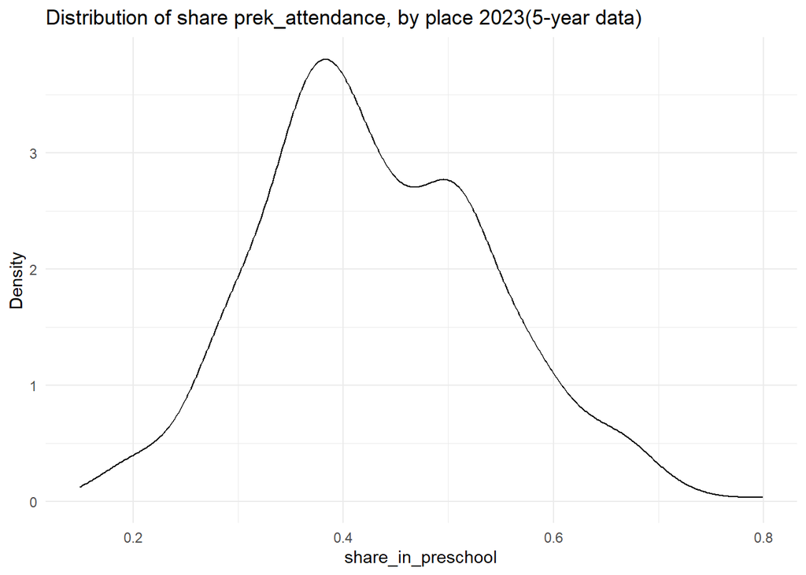

```r
metrics_education_all %>%
  filter(year == params$year) %>%
  select(share_in_preschool) %>%
  ggplot(aes(x = share_in_preschool)) +
  geom_density(alpha = 0.15) +
  theme_minimal() +
  ggtitle(paste0("Distribution of share prek_attendance, by place ", params$year, "(5-year data)")) +
  ylab("Density")
```

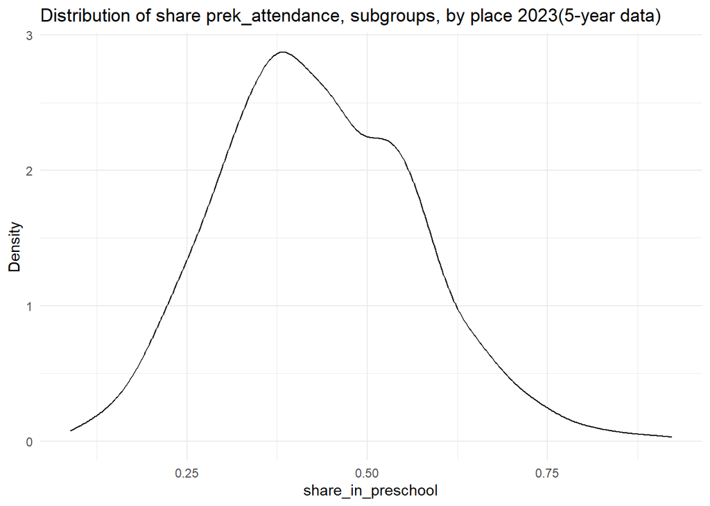

```r
metrics_education_sub %>%
  filter(year == params$year, subgroup != "All") %>%
  select(share_in_preschool) %>%
  ggplot(aes(x = share_in_preschool)) +
  geom_density(alpha = 0.15) +
  theme_minimal() +
  ggtitle(paste0("Distribution of share prek_attendance, subgroups, by place ", params$year, "(5-year data)")) +
  ylab("Density")
```

Look at distribution of prek_attendance share by place for each individual subgroup.

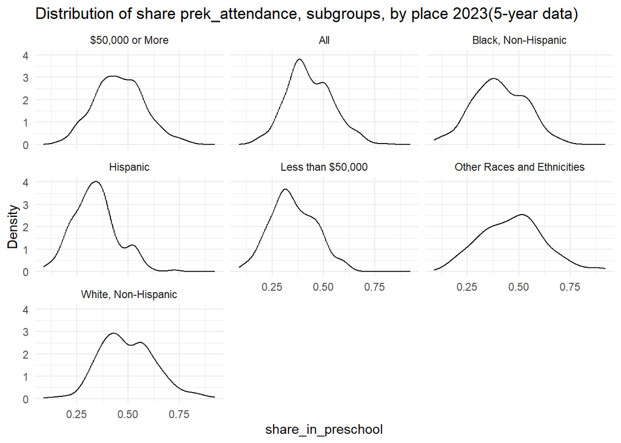

```r
metrics_education_sub %>%
  filter(year == params$year) %>%
  ggplot(aes(x = share_in_preschool)) +
  geom_density(alpha = 0.15) +
  facet_wrap(~subgroup) +
  labs(
    title = paste0("Distribution of share prek_attendance, subgroups, by place ", params$year, "(5-year data)"),
    y = "Density"
  ) +
  theme_minimal()
```

### Time trends

Compare trends for the share in preschool overtime for all years in the data.

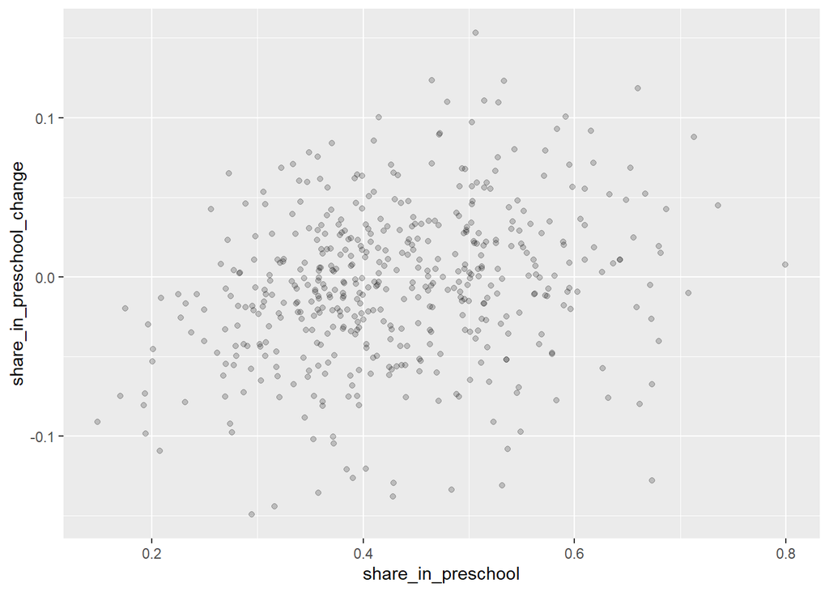

```r
metrics_education_all %>%
  group_by(statefip, place) %>%
  mutate(share_in_preschool_change = share_in_preschool - lag(share_in_preschool)) %>%
  filter(year == params$year) %>%
  ggplot(aes(share_in_preschool, share_in_preschool_change)) +
  geom_point(alpha = 0.2)
```

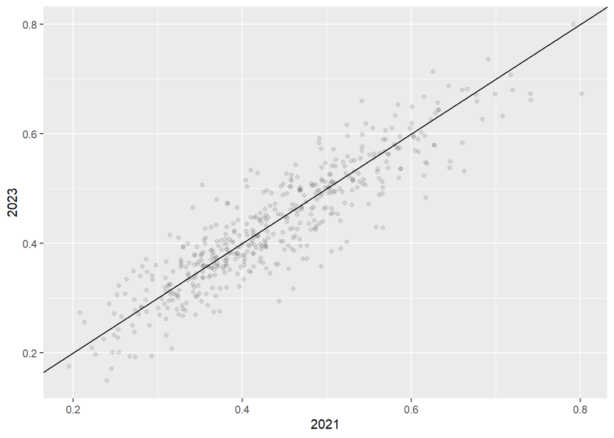

```r
metrics_education_all %>%
  select(year, statefip, place, share_in_preschool) %>%
  pivot_wider(
    names_from = year,
    values_from = share_in_preschool
  ) %>%
  ggplot(aes(`2021`, `2023`)) +
  geom_abline() +
  geom_point(alpha = 0.1)
```

### Confidence intervals

Check the missingness pattern for confidence intervals.

```r
nonmissing <- metrics_education_all |>
  filter(!is.na(share_in_preschool) & !is.na(share_in_preschool_lb) & !is.na(share_in_preschool_ub))

missing <- metrics_education_all |>
  filter(is.na(share_in_preschool) & is.na(share_in_preschool_lb) & is.na(share_in_preschool_ub))

stopifnot(nrow(nonmissing) + nrow(missing) == nrow(metrics_education_all))
```

Check the order. There are three variables and we are interested in pairwise comparisons, we can test that these line up. The upper-bound value should always be greater than the value and the lower-bound value. The value should always be greater than the lower-bound value.

```r
# upper bound is always greater than the estimate
stopifnot(all(nonmissing$share_in_preschool_ub > nonmissing$share_in_preschool))

# upper bound is always greater than the lower bound
stopifnot(all(nonmissing$share_in_preschool_ub > nonmissing$share_in_preschool_lb))

# estimate is always greater than the lower bound
stopifnot(all(nonmissing$share_in_preschool > nonmissing$share_in_preschool_lb))
```

Look at confidence intervals.

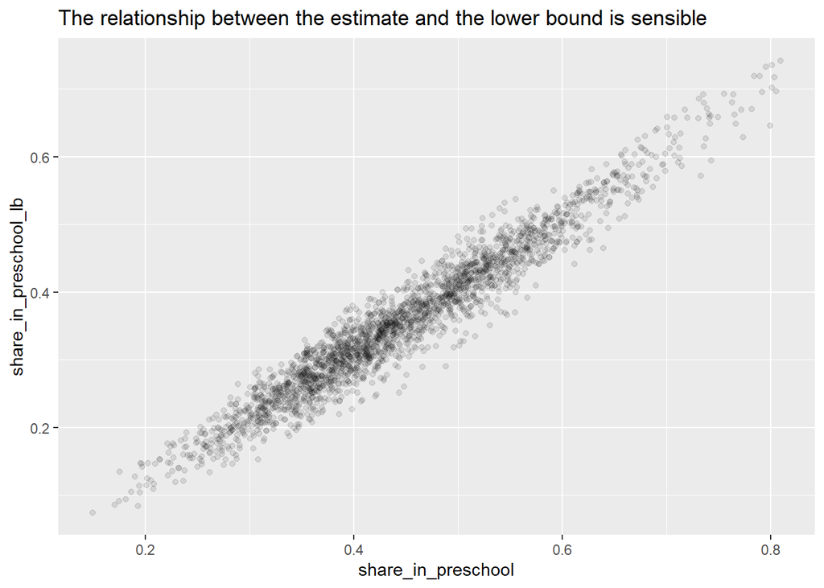

```r
metrics_education_all %>%
  ggplot(aes(share_in_preschool, share_in_preschool_lb)) +
  geom_point(alpha = 0.1) +
  labs(title = "The relationship between the estimate and the lower bound is sensible")
```

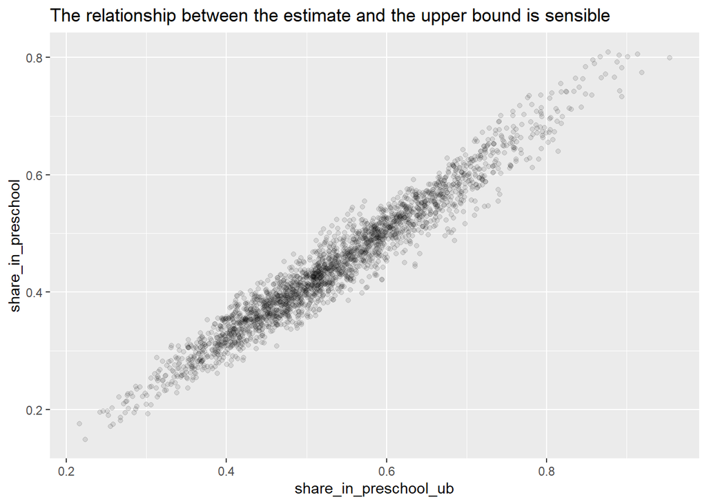

```r
metrics_education_all %>%
  ggplot(aes(share_in_preschool_ub, share_in_preschool)) +
  geom_point(alpha = 0.1) +
  labs(title = "The relationship between the estimate and the upper bound is sensible")
```

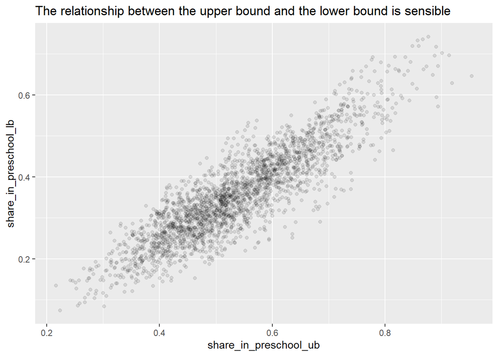

```r
metrics_education_all %>%
  ggplot(aes(share_in_preschool_ub, share_in_preschool_lb)) +
  geom_point(alpha = 0.1) +
  labs(title = "The relationship between the upper bound and the lower bound is sensible")
```

Distribution of confidence interval widths.

```r
metrics_education_all %>%
  mutate(ci_width = share_in_preschool_ub - share_in_preschool_lb) %>%
  pull(ci_width) %>%
  summary(na.rm = TRUE)
```

```
   Min. 1st Qu.  Median    Mean 3rd Qu.    Max.    NA's
0.02585 0.14469 0.17726 0.17990 0.21384 0.39442      10
```

### Quality and suppression

Look at the counts of the quality flag.

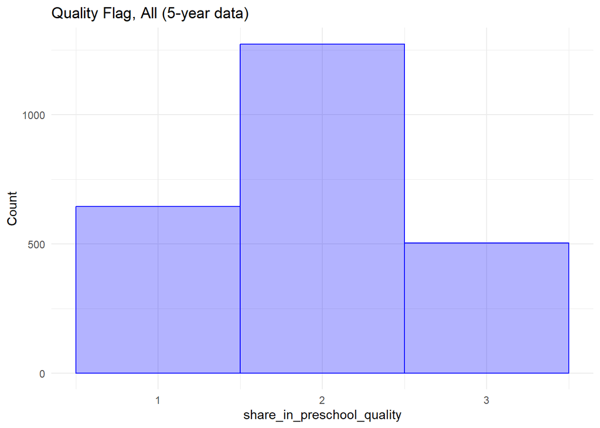

```r
metrics_education_all %>%
  select(share_in_preschool_quality) %>%
  ggplot(aes(x = share_in_preschool_quality)) +
  geom_histogram(color = "blue", fill = alpha("blue", 0.3), binwidth = 1.0) +
  theme_minimal() +
  ggtitle("Quality Flag, All (5-year data)") +
  ylab("Count")
```

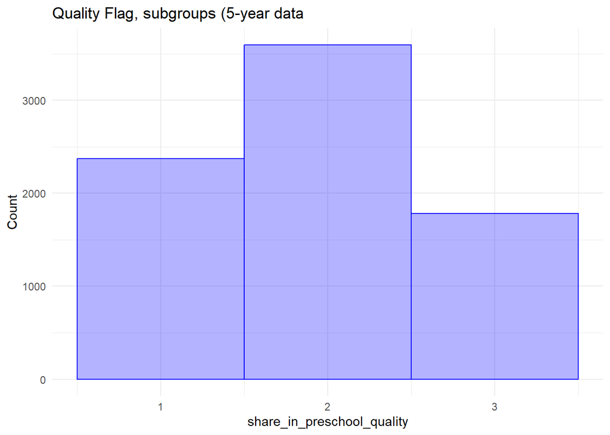

```r
metrics_education_sub %>%
  filter(subgroup != "All") %>%
  select(share_in_preschool_quality) %>%
  ggplot(aes(x = share_in_preschool_quality)) +
  geom_histogram(color = "blue", fill = alpha("blue", 0.3), binwidth = 1.0) +
  theme_minimal() +
  ggtitle("Quality Flag, subgroups (5-year data") +
  ylab("Count")
```

Look at quality by each individual subgroup.

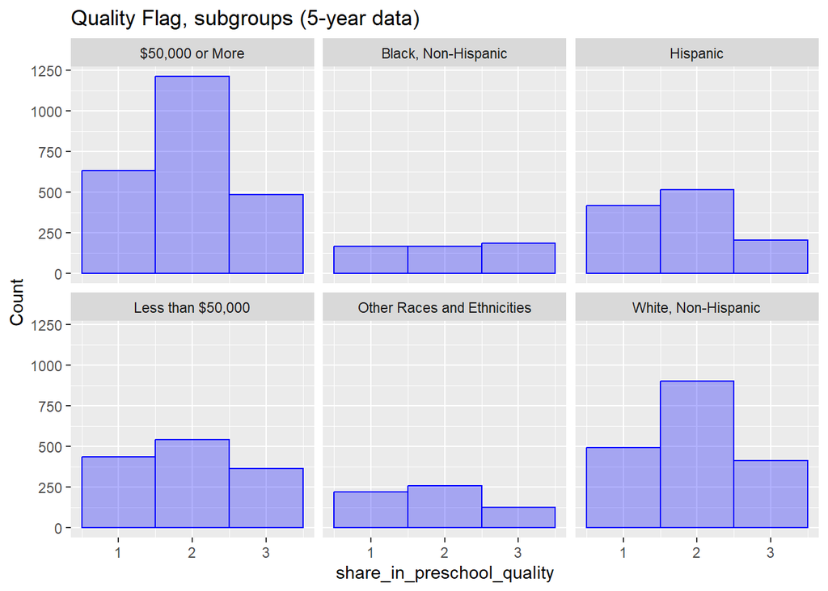

```r
metrics_education_sub %>%
  filter(subgroup != "All") %>%
  ggplot(aes(x = share_in_preschool_quality)) +
  geom_histogram(color = "blue", fill = alpha("blue", 0.3), binwidth = 1.0) +
  facet_wrap(~subgroup) +
  ggtitle("Quality Flag, subgroups (5-year data)") +
  ylab("Count")
```

Tabulate share of data suppressed by year.

```r
metrics_education_all %>%
  group_by(year) %>%
  summarise(suppressed = sum(is.na(share_in_preschool)),
            total = n(),
            suppressed_share = suppressed/total)
```

```
# A tibble: 5 x 4
   year suppressed total suppressed_share
  <dbl>      <int> <int>            <dbl>
1  2014          4   486          0.00823
2  2016          2   486          0.00412
3  2018          2   486          0.00412
4  2021          2   486          0.00412
5  2023          0   486          0
```

```r
metrics_education_sub %>%
  filter(subgroup != "All") %>%
  group_by(year, subgroup) %>%
  summarise(suppressed = sum(is.na(share_in_preschool)),
            total = n(),
            suppressed_share = suppressed/total)
```

```
# A tibble: 30 x 5
# Groups:   year [5]
    year subgroup                    suppressed total suppressed_share
   <dbl> <chr>                            <int> <int>            <dbl>
 1  2014 $50,000 or More                     75   486           0.154
 2  2014 Black, Non-Hispanic                383   486           0.788
 3  2014 Hispanic                           291   486           0.599
 4  2014 Less than $50,000                  196   486           0.403
 5  2014 Other Races and Ethnicities        410   486           0.844
 6  2014 White, Non-Hispanic                166   486           0.342
 7  2016 $50,000 or More                      9   486           0.0185
 8  2016 Black, Non-Hispanic                369   486           0.759
 9  2016 Hispanic                           235   486           0.484
10  2016 Less than $50,000                  148   486           0.305
# i 20 more rows
```

## Final Test and Export

Rename state.

```r
metrics_education_all <- metrics_education_all %>%
  rename("state" = "statefip")

metrics_education_sub <- metrics_education_sub %>%
  rename("state" = "statefip")
```

Order the variables how we want.

```r
metrics_education_all <- metrics_education_all %>%
  select(year, state, place, share_in_preschool,
         share_in_preschool_lb, share_in_preschool_ub, share_in_preschool_quality) %>%
  arrange(year, state, place)

metrics_education_sub <- metrics_education_sub %>%
  select(year, state, place, subgroup_type, subgroup, share_in_preschool,
         share_in_preschool_lb, share_in_preschool_ub, share_in_preschool_quality) %>%
  arrange(year, state, place, subgroup_type, subgroup)
```

Run file through evaluate final data function.

All.

```r
evaluate_final_data(data = metrics_education_all, exp_form_path = here::here("10a_final-evaluation", "evaluation_form_preschool_overall_place.csv"), geography = "place", subgroups = FALSE, confidence_intervals = TRUE)
```

```
[1] "This data passes all tests!"
```

Race-ethnicity.

```r
metrics_education_race <- metrics_education_sub %>%
  filter(subgroup_type %in% c("all", "race-ethnicity"))

evaluate_final_data(data = metrics_education_race, exp_form_path = here::here("10a_final-evaluation", "evaluation_form_preschool_race_eth_place.csv"), geography = "place", subgroups = TRUE, confidence_intervals = TRUE)
```

```
[1] "This data passes all tests!"
```

Income.

```r
metrics_education_income <- metrics_education_sub %>%
  filter(subgroup_type %in% c("all", "income"))

evaluate_final_data(data = metrics_education_income, exp_form_path = here::here("10a_final-evaluation", "evaluation_form_preschool_income_place.csv"), geography = "place", subgroups = TRUE, confidence_intervals = TRUE)
```

```
[1] "This data passes all tests!"
```

### Export as CSV

```r
metrics_education_all %>%
  head(10)
```

```
# A tibble: 10 x 7
    year state place share_in_preschool share_in_preschool_lb
   <dbl> <chr> <chr>              <dbl>                 <dbl>
 1  2014 01    03076              0.438                 0.336
 2  2014 01    07000              0.368                 0.271
 3  2014 01    35896              0.495                 0.406
 4  2014 01    37000              0.342                 0.258
 5  2014 01    50000              0.451                 0.354
 6  2014 01    51000              0.519                 0.444
 7  2014 01    77256              0.362                 0.251
 8  2014 02    03000              0.364                 0.276
 9  2014 04    04720              0.186                 0.105
10  2014 04    07940              0.347                 0.232
# i 2 more variables: share_in_preschool_ub <dbl>,
#   share_in_preschool_quality <dbl>
```

```r
write_csv(metrics_education_all,
          here::here("08_education", "data", "final", "metrics_preschool_place_all_longitudinal_all.csv")
          )

metrics_education_race %>%
  head(10)
```

```
# A tibble: 10 x 9
    year state place subgroup_type  subgroup                  share_in_preschool
   <dbl> <chr> <chr> <chr>          <chr>                                  <dbl>
 1  2014 01    03076 all            All                                    0.438
 2  2014 01    03076 race-ethnicity Black, Non-Hispanic                   NA
 3  2014 01    03076 race-ethnicity Hispanic                              NA
 4  2014 01    03076 race-ethnicity Other Races and Ethnicit~             NA
 5  2014 01    03076 race-ethnicity White, Non-Hispanic                    0.424
 6  2014 01    07000 all            All                                    0.368
 7  2014 01    07000 race-ethnicity Black, Non-Hispanic                    0.366
 8  2014 01    07000 race-ethnicity Hispanic                              NA
 9  2014 01    07000 race-ethnicity Other Races and Ethnicit~             NA
10  2014 01    07000 race-ethnicity White, Non-Hispanic                   NA
# i 3 more variables: share_in_preschool_lb <dbl>, share_in_preschool_ub <dbl>,
#   share_in_preschool_quality <dbl>
```

```r
write_csv(metrics_education_race, here::here("08_education", "data", "final",
                                             "metrics_preschool_place_race-ethnicity_longitudinal.csv"))

metrics_education_income %>%
  head(10)
```

```
# A tibble: 10 x 9
    year state place subgroup_type subgroup          share_in_preschool
   <dbl> <chr> <chr> <chr>         <chr>                          <dbl>
 1  2014 01    03076 all           All                            0.438
 2  2014 01    03076 income        $50,000 or More                0.478
 3  2014 01    03076 income        Less than $50,000              0.409
 4  2014 01    07000 all           All                            0.368
 5  2014 01    07000 income        $50,000 or More                0.494
 6  2014 01    07000 income        Less than $50,000              0.318
 7  2014 01    35896 all           All                            0.495
 8  2014 01    35896 income        $50,000 or More                0.553
 9  2014 01    35896 income        Less than $50,000             NA
10  2014 01    37000 all           All                            0.342
# i 3 more variables: share_in_preschool_lb <dbl>, share_in_preschool_ub <dbl>,
#   share_in_preschool_quality <dbl>
```

```r
write_csv(metrics_education_income, here::here("08_education", "data", "final",
                                               "metrics_preschool_place_income_longitudinal.csv"))
```